# Exercise 1 (20 minutes)

You practice: joining two sources, OLS diagnostics (outliers & linearity) and a categorical predictor. Today's question: does state control of the economy go with higher emissions? When you're done, assist some of the others …

1. Do the Setup, if you have not yet done so.
2. Start a new R script and copy in this starter code. It is the lecture's World Bank pipeline, **joined to V-Dem** — the same join you practised in Lecture 2:

```r
pacman::p_load(
  tidyverse,    # Data manipulation & figures
  wbstats,      # World Bank data via API
  vdemdata,     # Varieties of Democracy data
  estimatr,     # OLS with robust standard errors
  modelsummary  # Nicely formatted regression tables
)

# World Bank: CO2 and GDP per person, most recent year we observe both
Dat_co2 <- wb_data(c(co2 = "EN.GHG.CO2.PC.CE.AR5",
                     gdp = "NY.GDP.PCAP.PP.KD"),
                   start_date = 2000, end_date = 2026) %>%
  rename(country_text_id = iso3c, year = date) %>% # Rename to V-Dem's key
  select(country_text_id, country, year, co2, gdp) %>%
  drop_na(co2, gdp) %>%
  group_by(country) %>%
  filter(year == max(year)) %>%
  ungroup() %>%
  mutate(gdp_k = gdp / 1000)

# V-Dem: state ownership of the economy (our "how socialist is it?" measure)
Dat_vdem <- vdem %>%
  as_tibble() %>%
  select(country_text_id, year, state_own_raw = v2clstown) %>%
  mutate(state_ownership = -state_own_raw) # Reverse: higher = MORE state ownership

# Region & income group, as in the lecture
Dat_meta <- wb_countries() %>%
  select(country_text_id = iso3c, region, income_level)

# The join: a country is identified by its ISO code AND the year
Dat <- Dat_co2 %>%
  inner_join(Dat_vdem, by = c("country_text_id", "year")) %>% #<<
  inner_join(Dat_meta, by = "country_text_id")
```

> **Stuck?**
> - Did the `pacman::p_load(...)` line run without red error messages? If not, fix that first.
> - Strange results? Start fresh: *Session → Restart R*, then rerun your script from the top.
> - **World Bank API down or very slow?** Load our cached, ready-made `Dat` instead: download [`Dat_L4_ex1.rds`](https://merlin-ols.netlify.app/data/Dat_L4_ex1.rds) into your project folder, then `Dat <- readRDS("Dat_L4_ex1.rds")`
> - Still stuck? Ask (and answer!) in the [t-R-ouble forum](https://absalon.ku.dk/courses/70545/discussion_topics/563046?module_item_id=2037268) on Absalon.
3. **First, check what the join cost you.** The World Bank gives us ~190 countries, but `Dat` has rows. Nothing went wrong — V-Dem simply does not code every microstate. (Our Lecture 4 artefact, **Palau**, is one of the countries it drops.) *An `inner_join()` is a silent filter: always look at the row count.*
4. **Now write it yourself.** The World Bank sorts countries into four *income groups*. Make `income_level` an ordered **factor** with **`"Low income"` as the reference**, then regress `co2` on it with `lm_robust()`. *(This is today's categorical-predictor skill.)*

Use `fct_relevel()` inside `mutate()` to set the reference level, then `lm_robust(co2 ~ income_level, data = Dat)`.

```r
Dat <- Dat %>%
  mutate(income_level = fct_relevel(income_level, "Low income"))

ols_inc <- lm_robust(co2 ~ income_level, data = Dat)

modelsummary(list("CO2 per person" = ols_inc), stars = TRUE,
             coef_rename = c("income_levelLower middle income" = "Lower middle",
                             "income_levelUpper middle income" = "Upper middle",
                             "income_levelHigh income" = "High income"),
             gof_map = c("nobs", "r.squared"))
```

|  | CO2 per person |
| --- | --- |
| (Intercept) | 0.237*** |
|  | (0.061) |
| High income | 8.275*** |
|  | (1.024) |
| Lower middle | 0.833*** |
|  | (0.143) |
| Upper middle | 3.892*** |
|  | (0.418) |
| Num.Obs. | 165 |
| R2 | 0.339 |

+ p < 0.1, * p < 0.05, ** p < 0.01, *** p < 0.001

5. Read off your table: on average, high-income countries emit tonnes of CO₂ per person **more** than low-income countries (two digits; point or comma is fine).
6. **Write one sentence** in your R script (as a `# comment`) interpreting that coefficient — *descriptively*, as in the lecture. Then compare:

*Across the world's countries, high-income countries emit on average about 8.3 tonnes more CO₂ per person than low-income countries — a difference of group means, not (yet) a causal effect.*

(Name the **direction**, the rough **size**, and the **units** — and use associational, not causal, language.)

7. Now the **continuous** predictor, and today's real question: **does state control of the economy go with higher emissions?** Make a scatter plot with `co2` on the Y-axis and `state_ownership` on the X-axis. Ask it the four questions: *direction, form, spread, outliers*.

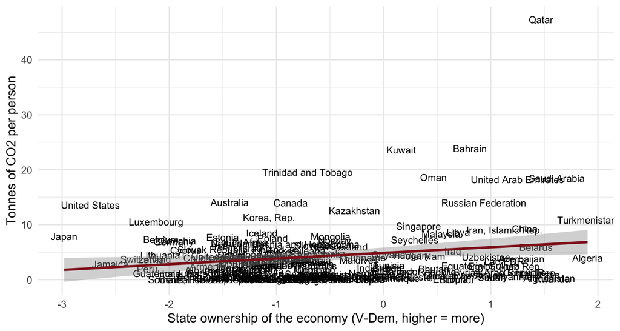

```r
ggplot(data = Dat, aes(y = co2, x = state_ownership)) +
  geom_text(aes(label = country), size = 3) +
  geom_smooth(method = "lm", formula = y ~ x, color = "#901A1E") +
  labs(y = "Tonnes of CO2 per person",
       x = "State ownership of the economy (V-Dem, higher = more)") +
  theme_minimal()
```

8. **Before you compute anything:** judging only from your scatter plot, the correlation between `co2` and `state_ownership` is …
9. Fit `lm_robust(co2 ~ state_ownership, data = Dat)`. The slope is **positive** — tempting headline: *state-run economies pollute more.* But look at how big its standard error is, then re-fit with base `lm()` and run the two diagnostic plots. Which statement fits what you see?

```r
ols_state <- lm_robust(co2 ~ state_ownership, data = Dat)
modelsummary(list("CO2 per person" = ols_state), stars = TRUE,
             gof_map = c("nobs", "r.squared"))
```

|  | CO2 per person |
| --- | --- |
| (Intercept) | 4.869*** |
|  | (0.722) |
| state_ownership | 1.030 |
|  | (0.634) |
| Num.Obs. | 165 |
| R2 | 0.036 |

+ p < 0.1, * p < 0.05, ** p < 0.01, *** p < 0.001

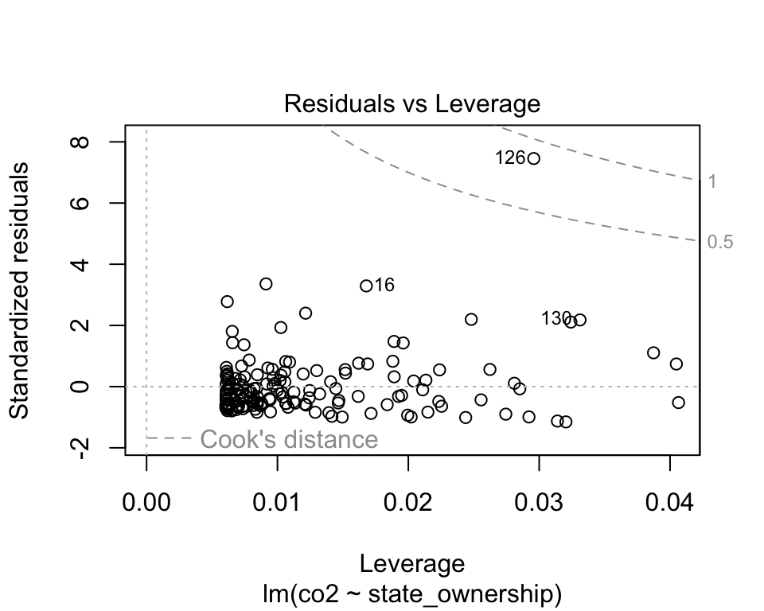

```r
mod <- lm(co2 ~ state_ownership, data = Dat)
plot(mod, which = 5) # Outliers (Cook's D)
```

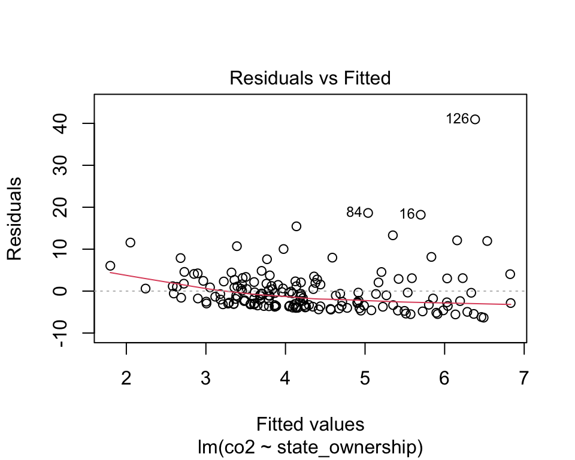

```r
plot(mod, which = 1) # Linearity
```

**Bonus (for the fast):** those Gulf states nationalised their **oil**, which is a very different thing from a socialist economy. Flag the **petro economies** the way the lecture did — fuel rents above 10% of GDP — drop them, and re-fit. Does the headline survive?

```r
# Oil + gas rents, same definition as the lecture's "Petro vs. rest" panel
petro_flag <- wb_data(c(oil = "NY.GDP.PETR.RT.ZS",
                        gas = "NY.GDP.NGAS.RT.ZS"),
                      start_date = 2000, end_date = 2026) %>%
  drop_na(oil, gas) %>%              # Years with both rent series
  mutate(rents = oil + gas) %>%      # Oil + gas rents, in % of GDP
  group_by(iso3c) %>% filter(date == max(date)) %>% ungroup() %>%
  select(country_text_id = iso3c, rents)

Dat <- Dat %>%
  left_join(petro_flag, by = "country_text_id") %>% # keeps countries without rents data
  mutate(petro = case_when(
    rents > 10 ~ "Petro economy",       # fuel rents above 10% of GDP
    TRUE ~ "Other country"))

m_all   <- lm_robust(co2 ~ state_ownership, data = Dat)
m_noOil <- lm_robust(co2 ~ state_ownership, data = Dat %>% filter(petro == "Other country"))

modelsummary(list("All countries" = m_all, "Without petro economies" = m_noOil),
             stars = TRUE, gof_map = c("nobs", "r.squared"))
```

|  | All countries | Without petro economies |
| --- | --- | --- |
| (Intercept) | 4.869*** | 2.773*** |
|  | (0.722) | (0.348) |
| state_ownership | 1.030 | -0.654* |
|  | (0.634) | (0.309) |
| Num.Obs. | 165 | 141 |
| R2 | 0.036 | 0.032 |

+ p < 0.1, * p < 0.05, ** p < 0.01, *** p < 0.001

Look at what happens. With every country in, the slope is positive but its confidence interval comfortably includes zero — there was never a solid finding to report. Drop the petro economies and the slope **flips sign** and *becomes* significant: among the other 141 countries, *more* state ownership goes with **less** CO₂ per person.

So the "state-run economies pollute" headline was never about socialism. It was a couple of dozen petro economies that happen to keep their oil and gas in state hands — exactly the countries the diagnostic plots flagged in step 9.

Two footnotes worth knowing. (1) Plain `lm()` would have called the first slope significant ($p$ = 0.015); `lm_robust()` does not ($p$ = 0.11), because those same petro outliers make the errors wildly heteroscedastic. That is *why* we use robust standard errors. (2) Dropping cases you dislike is not a licence to hunt for the answer you want — it is a **robustness check**, and the honest write-up reports *both* models. Remember that for your term paper.

**Special (for the very fast):** you have only ever controlled for *nothing* so far. Wealth is the obvious rival explanation — so put `gdp_k` in the model alongside `state_ownership` and see what happens to the slope. (This is **Lecture 8**'s skill; today just run it and look.)

```r
m_biv <- lm_robust(co2 ~ state_ownership, data = Dat)
m_mlt <- lm_robust(co2 ~ state_ownership + gdp_k, data = Dat) #<<

modelsummary(list("Bivariate" = m_biv, "Controlling for wealth" = m_mlt),
             stars = TRUE, gof_map = c("nobs", "r.squared"))
```

|  | Bivariate | Controlling for wealth |
| --- | --- | --- |
| (Intercept) | 4.869*** | 1.457** |
|  | (0.722) | (0.449) |
| state_ownership | 1.030 | 1.627** |
|  | (0.634) | (0.533) |
| gdp_k |  | 0.143*** |
|  |  | (0.031) |
| Num.Obs. | 165 | 165 |
| R2 | 0.036 | 0.475 |

+ p < 0.1, * p < 0.05, ** p < 0.01, *** p < 0.001

Surprise: controlling for wealth does not shrink the slope, it makes it **bigger** (about 1.03 → 1.63) and now clearly significant, while $R^2$ jumps from about 0.04 to 0.48. That happens because state ownership is mildly *negatively* correlated with wealth (r ≈ −0.16): state-run economies tend to be **poorer**, and poverty holds emissions down. Wealth was **masking** the association, not inflating it — you will meet this as a *suppressor* in Lecture 8.

**Now put the two bonuses together.** Fit all four models — with and without the petro economies, with and without the wealth control — and read the pattern.

```r
modelsummary(
  list("All"            = lm_robust(co2 ~ state_ownership, data = Dat),
       "All + wealth"   = lm_robust(co2 ~ state_ownership + gdp_k, data = Dat),
       "No petro"       = lm_robust(co2 ~ state_ownership, data = Dat %>% filter(petro == "Other country")),
       "No petro + wealth" = lm_robust(co2 ~ state_ownership + gdp_k, data = Dat %>% filter(petro == "Other country"))),
  stars = TRUE, gof_map = c("nobs", "r.squared"))
```

|  | All | All + wealth | No petro | No petro + wealth |
| --- | --- | --- | --- | --- |
| (Intercept) | 4.869*** | 1.457** | 2.773*** | 1.082*** |
|  | (0.722) | (0.449) | (0.348) | (0.265) |
| state_ownership | 1.030 | 1.627** | -0.654* | 0.142 |
|  | (0.634) | (0.533) | (0.309) | (0.220) |
| gdp_k |  | 0.143*** |  | 0.093*** |
|  |  | (0.031) |  | (0.012) |
| Num.Obs. | 165 | 165 | 141 | 141 |
| R2 | 0.036 | 0.475 | 0.032 | 0.496 |

+ p < 0.1, * p < 0.05, ** p < 0.01, *** p < 0.001